# chapter_13_solutions

1 Exercise 13.1. Two-class classification with neural networks

2 Exercise 13.2. Multi-class classification with neural networks

3 Exercise 13.3. Number of weights to learn in a neural network

4 Exercise 13.4. Nonlinear Autoencoder using neural networks

5 Exercise 13.5. The maxout activation function

6 Exercise 13.6. Comparing advanced first-order optimizers I

7 Exercise 13.7. Comparing advanced first-order optimizers II

8 Exercise 13.8. Batch normalization

9 Exercise 13.9. Early stopping cross-validation

10 Exercise 13.10. Handwritten digit recognition using neural networks

11 CONTRAST NORMALIZE IMAGES

12 Split into training / validation

```python
# import basic libraries and autograd wrapped numpy
import sys
sys.path.append('../')
datapath = '../mlrefined_datasets/nonlinear_superlearn_datasets/'
import autograd.numpy as np
import matplotlib.pyplot as plt
from matplotlib import gridspec

# imports from custom library
from mlrefined_libraries import nonlinear_superlearn_library as nonlib
from mlrefined_libraries import multilayer_perceptron_library as multi
from mlrefined_libraries import math_optimization_library as optlib
basic_runner = nonlib.basic_runner
regress_plotter = nonlib.nonlinear_regression_demos
classif_plotter = nonlib.nonlinear_classification_demos
static_plotter = optlib.static_plotter.Visualizer()

# This is needed to compensate for %matplotlib notebook's tendancy to blow up images when plotted inline
from matplotlib import rcParams
rcParams['figure.autolayout'] = True
%matplotlib notebook
```

# Exercise 13.1. Two-class classification with neural networks

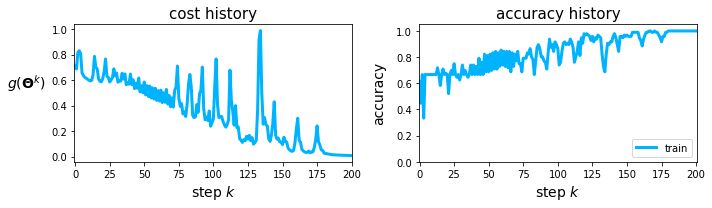

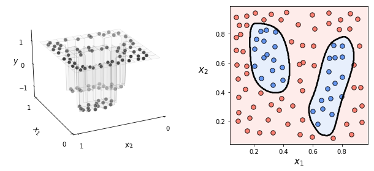

```python
# This code cell will not be shown in the HTML version of this notebook
# create instance of linear regression demo, used below and in the next examples
demo = multi.nonlinear_classification_visualizer.Visualizer(datapath + '2_eggs.csv')
x = demo.x.T
y = demo.y[np.newaxis,:]

# an implementation of the least squares cost function for linear regression for N = 2 input dimension datasets
# demo5.plot_data();

# An example 4 hidden layer network, with 10 units in each layer
N = 2  # dimension of input
M = 1  # dimension of output
U_1 = 10; U_2 = 10; U_3 = 10;  # number of units per hidden layer

# the list defines our network architecture
layer_sizes = [N, U_1,U_2,U_3,M]

# initialize with input/output data
mylib1 = multi.basic_lib.super_setup.Setup(x,y)

# perform preprocessing step(s) - especially input normalization
mylib1.preprocessing_steps(normalizer = 'standard')

# split into training and validation sets
mylib1.make_train_val_split(train_portion = 1)

# choose cost
mylib1.choose_cost(name = 'softmax')

# choose dimensions of fully connected multilayer perceptron layers
layer_sizes = [10,10,10,10]
mylib1.choose_features(feature_name = 'multilayer_softmax',layer_sizes = layer_sizes,activation = 'tanh',scale = 0.5)

# fit an optimization
mylib1.fit(max_its = 200,alpha_choice = 10**(0),verbose = False)

# plot cost function history
mylib1.show_histories()

# illustrate results
ind = np.argmax(mylib1.train_accuracy_histories[0])
w_best = mylib1.weight_histories[0][ind]
demo.static_N2_simple(w_best,mylib1,view = [30,155])
```

# Exercise 13.2. Multi-class classification with neural networks

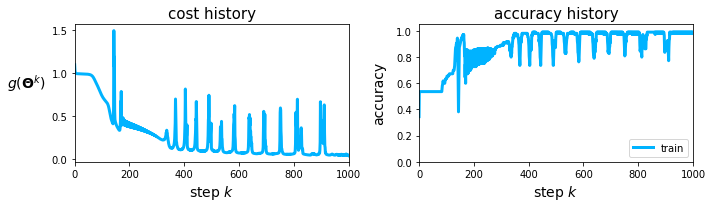

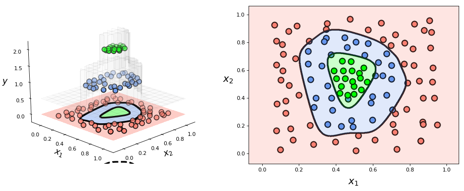

```python
# create an instance of a multiclass classification visualizer
demo = multi.nonlinear_classification_visualizer.Visualizer(datapath + '3_layercake_data.csv')
x = demo.x.T
y = demo.y[np.newaxis,:]

# define the number fo units to use in each layer
N = 2         # dimension of input
U_1 = 12      # number of single layer units to employ
U_2 = 5       # number of two layer units to employ
C = 3

# package all weights together in a single list
w = [N,U_1,U_2,C]

# initialize with input/output data
mylib = multi.basic_lib.super_setup.Setup(x,y)

# perform preprocessing step(s) - especially input normalization
mylib.preprocessing_steps(normalizer = 'standard')

# split into training and validation sets
mylib.make_train_val_split(train_portion = 1)

# choose cost
mylib.choose_cost(name = 'multiclass_softmax')

# choose dimensions of fully connected multilayer perceptron layers
layer_sizes = [12,5]
mylib.choose_features(feature_name = 'multilayer_perceptron',layer_sizes = layer_sizes,activation = 'tanh',scale = 0.1)

# fit an optimization
mylib.fit(max_its = 1000,alpha_choice = 10**(0),verbose = False)

# plot cost function history
mylib.show_histories()

# pluck out best weights - those that provided lowest cost,
# and plot resulting fit
ind = np.argmax(mylib.train_accuracy_histories[0])
w_best = mylib.weight_histories[0][ind]

# plot result of nonlinear multiclass classification
demo.multiclass_plot(mylib,w_best)
```

# Exercise 13.3. Number of weights to learn in a neural network

a) Assuming $U_{j}$ units per hidden-layer in layers $j=1$ through $j=L$, and additionally defining $U_{0}=N$ and $U_{L+1}=1$, the total number of parameters in a fully-connected feed forward neural network with $L$ hidden-layers can be written as

$$Q=\underset{j=0}{\overset{L}{\sum}}\left(1+U_{j}\right)U_{j+1}.$$

b) $Q$ can be written equivalently as

$$Q=NU_1 + \left(U_1+\underset{j=1}{\overset{L}{\sum}}\left(1+U_{j}\right)U_{j+1}\right)$$

where the expression inside the parentheses is constant with respect to $N$. Note that $Q$ is independent of the number of data points $P$. This is not the case with kernel methods.

# Exercise 13.4. Nonlinear Autoencoder using neural networks

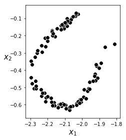

```python
# import data
X = np.loadtxt(datapath + 'universal_autoencoder_samples.csv',delimiter=',')

# scatter dataset
fig = plt.figure(figsize = (9,4))
gs = gridspec.GridSpec(1,1)
ax = plt.subplot(gs[0],aspect = 'equal');
ax.set_xlabel(r'$x_1$',fontsize = 15);ax.set_ylabel(r'$x_2$',fontsize = 15,rotation = 0);
ax.scatter(X[0,:],X[1,:],c = 'k',s = 60,linewidth = 0.75,edgecolor = 'w')
plt.show()
```

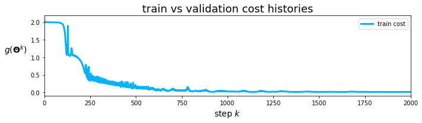

```python
# This code cell will not be shown in the HTML version of this notebook
# create instance of library
mylib = multi.basic_lib.unsuper_setup.Setup(X)

# perform preprocessing step(s) - especially input normalization
mylib.preprocessing_steps(normalizer = 'standard')

# split into training and validation sets
mylib.make_train_val_split(train_portion = 1)

# choose features
mylib.choose_encoder(layer_sizes = [2,10,10,1],scale = 0.2)
mylib.choose_decoder(layer_sizes = [1,10,10,2],scale = 0.2)

# choose cost
mylib.choose_cost(name = 'autoencoder')

# fit an optimization
mylib.fit(max_its = 2000,alpha_choice = 10**(-1),verbose = False)

# plot cost function history
mylib.show_histories()
```

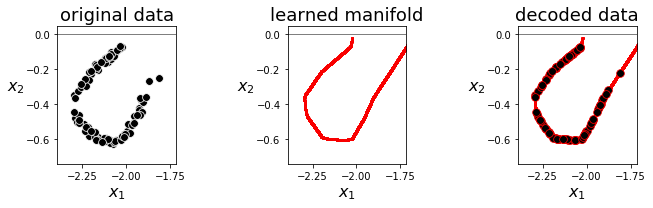

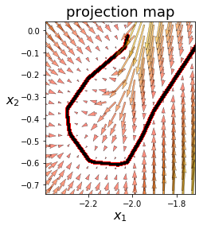

```python
# This code cell will not be shown in the HTML version of this notebook
# plot results
multi.autoencoder_demos.show_encode_decode(X,mylib,projmap = True,scale = 4.5)
```

# Exercise 13.5. The maxout activation function

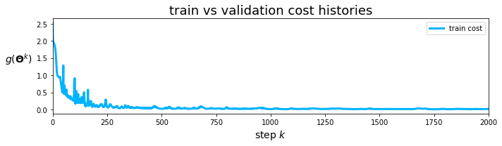

```python
# This code cell will not be shown in the HTML version of this notebook
# create instance of library
mylib = multi.basic_lib.unsuper_setup.Setup(X)

# perform preprocessing step(s) - especially input normalization
mylib.preprocessing_steps(normalizer = 'standard')

# split into training and validation sets
mylib.make_train_val_split(train_portion = 1)

# choose features
mylib.choose_encoder(layer_sizes = [2,10,10,1],scale = 0.2,activation='maxout')
mylib.choose_decoder(layer_sizes = [1,10,10,2],scale = 0.2,activation='maxout')

# choose cost
mylib.choose_cost(name = 'autoencoder')

# fit an optimization
mylib.fit(max_its = 2000,alpha_choice = 10**(-1),verbose = False)

# plot cost function history
mylib.show_histories()
```

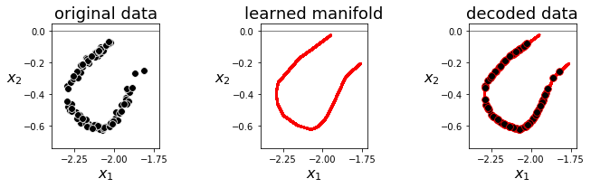

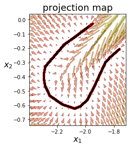

```python
# This code cell will not be shown in the HTML version of this notebook
# plot results
multi.autoencoder_demos.show_encode_decode(X,mylib,projmap = True,scale = 4.5)
```

# Exercise 13.6. Comparing advanced first-order optimizers I

Load in data.

```python
# get MNIST data from online repository
from sklearn.datasets import fetch_openml
x, y = fetch_openml('mnist_784', version=1, return_X_y=True)

# convert string labels to integers
y = np.array([int(v) for v in y])[:,np.newaxis]
```

```python
print("input shape = " , x.shape)
print("output shape = ", y.shape)
```

```
input shape =  (784, 70000)
output shape =  (1, 70000)
```

Randomly sample input / output pairs.

```python
# sample indices
num_sample = 50000
inds = np.random.permutation(y.shape[1])[:num_sample]
x_sample = x[:,inds]
y_sample = y[:,inds]
```

Implementation of multi-class cost and gradient descent optimizer that takes in mini-batches.

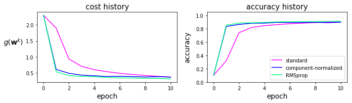

```python
# initialize with input/output data
mylib = multi.basic_lib.super_setup.Setup(x_sample,y_sample)

# perform preprocessing step(s) - especially input normalization
mylib.preprocessing_steps(normalizer = 'standard')

# split into training and validation sets
mylib.make_train_val_split(train_portion = 1)

# choose cost
mylib.choose_cost(name = 'multiclass_softmax')

# choose dimensions of fully connected multilayer perceptron layers
layer_sizes = [10,10,10,10]
mylib.choose_features(feature_name = 'multilayer_perceptron',layer_sizes = layer_sizes,activation = 'tanh',scale = 0.1)

### test optimizers ###
# standard gradient descent
mylib.fit(max_its = 10,alpha_choice = 10**(-1),verbose = False,batch_size = 200)

# component-wise normalized version
mylib.fit(max_its = 10,alpha_choice = 10**(-2),verbose = False,version = 'normalized',w_init = mylib.w_init,batch_size = 200)

# RMSprop
mylib.fit(algo = 'RMSprop',max_its = 10,alpha_choice = 10**(-2),verbose = False,w_init = mylib.w_init,batch_size = 200)

# plot cost function history
labels = ['standard','component-normalized','RMSprop']
mylib.show_multirun_histories(start = 0,labels = labels)
```

# Exercise 13.7. Comparing advanced first-order optimizers II

Before running the cell below make sure to run all the cells in the previous exercise first to load in the data.

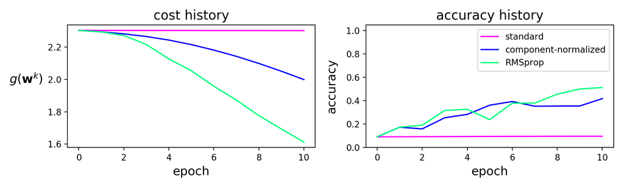

```python
# initialize with input/output data
mylib = multi.basic_lib.super_setup.Setup(x_sample,y_sample)

# perform preprocessing step(s) - especially input normalization
mylib.preprocessing_steps(normalizer = 'standard')

# split into training and validation sets
mylib.make_train_val_split(train_portion = 1)

# choose cost
mylib.choose_cost(name = 'multiclass_softmax')

# choose dimensions of fully connected multilayer perceptron layers
layer_sizes = [10,10,10,10]
mylib.choose_features(feature_name = 'multilayer_perceptron',layer_sizes = layer_sizes,activation = 'tanh',scale = 0.1)

### test optimizers ###
# standard gradient descent
mylib.fit(max_its = 10,alpha_choice = 10**(-1),verbose = False)

# component-wise normalized version
mylib.fit(max_its = 10,alpha_choice = 10**(-2),verbose = False,version = 'normalized',w_init = mylib1.w_init)

# RMSprop
mylib.fit(algo = 'RMSprop',max_its = 10,alpha_choice = 10**(-2),verbose = False,w_init = mylib1.w_init)

# plot cost function history
labels = ['standard','component-normalized','RMSprop']
mylib.show_multirun_histories(start = 0,labels = labels)
```

# Exercise 13.8. Batch normalization

Load in data.

```python
# get MNIST data from online repository
from sklearn.datasets import fetch_openml
x, y = fetch_openml('mnist_784', version=1, return_X_y=True)

# convert string labels to integers
y = np.array([int(v) for v in y])[:,np.newaxis]
```

```python
print("input shape = " , x.shape)
print("output shape = ", y.shape)
```

```
input shape =  (784, 70000)
output shape =  (1, 70000)
```

Randomly sample input / output pairs.

```python
# sample indices
num_sample = 50000
inds = np.random.permutation(y.shape[1])[:num_sample]
x_sample = x[:,inds]
y_sample = y[:,inds]

x_sample.shape
```

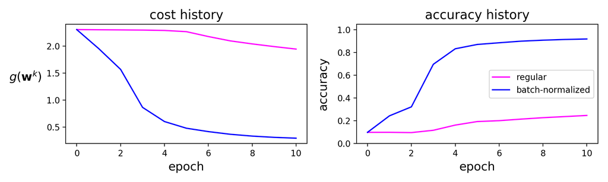

```python
# initialize with input/output data
mylib = multi.basic_lib.super_setup.Setup(x_sample,y_sample)

# perform preprocessing step(s) - especially input normalization
mylib.preprocessing_steps(normalizer = 'standard')

# split into training and validation sets
mylib.make_train_val_split(train_portion = 1)

# choose cost
mylib.choose_cost(name = 'multiclass_softmax')

# choose dimensions of fully connected multilayer perceptron layers
layer_sizes = [10,10,10,10]
mylib.choose_features(feature_name = 'multilayer_perceptron',layer_sizes = layer_sizes,activation = 'relu',scale = 0.1)
mylib.fit(max_its = 10,alpha_choice = 10**(-2),verbose = False,batch_size = 200)

# component-wise normalized version
mylib.choose_features(feature_name = 'multilayer_perceptron_batch_normalized',layer_sizes = layer_sizes,activation = 'relu',scale = 0.1)
mylib.fit(max_its = 10,alpha_choice = 10**(-1),verbose = False,w_init = mylib.w_init,batch_size = 200)

# plot cost function history
labels = ['regular','batch-normalized']
mylib.show_multirun_histories(start = 0,labels = labels)
```

# Exercise 13.9. Early stopping cross-validation

Below we illustrate the early stopping procedure using a simple nonlinear regression dataset (split into $\frac{2}{3}$ training and $\frac{1}{3}$ validation), and a (artbitrarily chosen) three hidden layer network with $10$ units per layer and the $\text{tanh}$ activation. A single run of gradient descent is illustrated below, as you move the slider left to right you can see the resulting fit at each highlighted step of the run in the original dataset (top left), training (bottom left), and validation data (bottom right). Moving the slider to where the validation error is lowest provides - for this training / validation split of the original data - a fine nonlinear model for the entire dataset.

```python
## This code cell will not be shown in the HTML version of this notebook
# load in dataset
csvname = datapath + 'noisy_sin_sample.csv'
data = np.loadtxt(csvname,delimiter = ',')
x = data[:-1,:]
y = data[-1:,:]

# show data
demo = regress_plotter.Visualizer(data)

# import the v1 library
mylib = nonlib.early_stop_lib.superlearn_setup.Setup(x,y)

# choose features
layer_sizes = [1,10,10,10,1]

# choose features
mylib.choose_features(name = 'multilayer_perceptron',layer_sizes = layer_sizes,activation = 'tanh')

# choose normalizer
mylib.choose_normalizer(name = 'standard')

# split into training and testing sets
mylib.make_train_valid_split(train_portion = 0.66)

# choose cost
mylib.choose_cost(name = 'least_squares')

# fit an optimization
mylib.fit(max_its = 10000,alpha_choice = 10**(-1))

# animate the business
frames = 20
demo = nonlib.early_stop_regression_animator.Visualizer(csvname)
demo.animate_trainval_earlystop(mylib,frames,show_history = True)
```

[figure not shown]

# Exercise 13.10. Handwritten digit recognition using neural networks

```python
# get MNIST data from online repository
from sklearn.datasets import fetch_openml
x, y = fetch_openml('mnist_784', version=1, return_X_y=True)

# convert string labels to integers
y = np.array([int(v) for v in y])[:,np.newaxis]
```

```python
print("input shape = " , x.shape)
print("output shape = ", y.shape)
```

```
input shape =  (784, 70000)
output shape =  (1, 70000)
```

# CONTRAST NORMALIZE IMAGES

```python
# standard normalization function - with nan checker / filler in-er
def standard_normalizer(x):
    # compute the mean and standard deviation of the input
    x_means = np.nanmean(x,axis = 1)[:,np.newaxis]
    x_stds = np.nanstd(x,axis = 1)[:,np.newaxis]

    # check to make sure thta x_stds > small threshold, for those not
    # divide by 1 instead of original standard deviation
    ind = np.argwhere(x_stds < 10**(-2))
    if len(ind) > 0:
        ind = [v[0] for v in ind]
        adjust = np.zeros((x_stds.shape))
        adjust[ind] = 1.0
        x_stds += adjust

    # fill in any nan values with means
    ind = np.argwhere(np.isnan(x) == True)
    for i in ind:
        x[i[0],i[1]] = x_means[i[0]]

    # create standard normalizer function
    normalizer = lambda data: (data - x_means)/x_stds

    # create inverse standard normalizer
    inverse_normalizer = lambda data: data*x_stds + x_means

    # return normalizer
    return normalizer,inverse_normalizer

normalizer,inverse_normalizer = standard_normalizer(x.T)
x = normalizer(x.T).T
```

# Split into training / validation

Randomly sample input / output pairs.

```python
# sample indices
num_sample = 60000
inds = np.random.permutation(y.shape[1])[:num_sample]
all_inds = np.random.permutation(y.shape[1])

#
train_inds = all_inds[:num_sample]
x_sample = x[:,train_inds]
y_sample = y[:,train_inds]

# test data
test_inds = all_inds[num_sample:]
x_test = x[:,test_inds]
y_test = y[:,test_inds]
```

Implementation of multi-class cost and gradient descent optimizer that takes in mini-batches.

```python
# import the v1 library
mylib2 = nonlib.early_stop_lib.superlearn_setup.Setup(x_sample,y_sample)

# choose features
layer_sizes = [784,100,100,10]

# choose features
mylib2.choose_features(name = 'multilayer_perceptron',layer_sizes = layer_sizes,activation = 'maxout',scale=0.1)

# choose normalizer
mylib2.choose_normalizer(name = 'standard')

# split into training and testing sets
mylib2.make_train_valid_split(train_portion = 5/6)

# choose cost
mylib2.choose_cost(name = 'multiclass_softmax')

# fit an optimization
mylib2.fit(optimizer = 'gradient_descent',max_its = 100,alpha_choice = 10**(-1),batch_size = 500,verbose = True,version = 'standard')
```

```
starting optimization...
step 1 done in 10.5 secs, train acc = 0.9088, valid acc = 0.8981
step 2 done in 10.9 secs, train acc = 0.9339, valid acc = 0.9189
step 3 done in 11.0 secs, train acc = 0.9467, valid acc = 0.9287
step 4 done in 11.9 secs, train acc = 0.956, valid acc = 0.936
step 5 done in 12.3 secs, train acc = 0.9625, valid acc = 0.9413
step 6 done in 11.7 secs, train acc = 0.9685, valid acc = 0.9436
step 7 done in 11.1 secs, train acc = 0.9723, valid acc = 0.9463
step 8 done in 9.6 secs, train acc = 0.9752, valid acc = 0.9479
step 9 done in 9.7 secs, train acc = 0.9782, valid acc = 0.9487
step 10 done in 10.0 secs, train acc = 0.9806, valid acc = 0.95
step 11 done in 9.5 secs, train acc = 0.9822, valid acc = 0.9517
step 12 done in 10.4 secs, train acc = 0.9838, valid acc = 0.9531
step 13 done in 9.9 secs, train acc = 0.9856, valid acc = 0.9538
step 14 done in 9.1 secs, train acc = 0.987, valid acc = 0.9539
step 15 done in 9.0 secs, train acc = 0.9884, valid acc = 0.9543
step 16 done in 9.7 secs, train acc = 0.9898, valid acc = 0.9548
step 17 done in 9.4 secs, train acc = 0.9907, valid acc = 0.9548
step 18 done in 10.5 secs, train acc = 0.9917, valid acc = 0.955
step 19 done in 11.5 secs, train acc = 0.9929, valid acc = 0.9555
step 20 done in 10.5 secs, train acc = 0.994, valid acc = 0.9558
step 21 done in 9.1 secs, train acc = 0.9947, valid acc = 0.9559
step 22 done in 8.8 secs, train acc = 0.9954, valid acc = 0.9558
step 23 done in 9.1 secs, train acc = 0.996, valid acc = 0.9562
step 24 done in 9.1 secs, train acc = 0.9965, valid acc = 0.9561
step 25 done in 9.3 secs, train acc = 0.9969, valid acc = 0.9564
step 26 done in 11.1 secs, train acc = 0.9973, valid acc = 0.9565
step 27 done in 11.8 secs, train acc = 0.9977, valid acc = 0.9568
step 28 done in 9.1 secs, train acc = 0.998, valid acc = 0.9568
step 29 done in 9.3 secs, train acc = 0.9983, valid acc = 0.9571
step 30 done in 9.3 secs, train acc = 0.9985, valid acc = 0.9575
step 31 done in 9.4 secs, train acc = 0.9987, valid acc = 0.9573
step 32 done in 11.3 secs, train acc = 0.9989, valid acc = 0.9573
step 33 done in 12.0 secs, train acc = 0.9991, valid acc = 0.9575
step 34 done in 11.1 secs, train acc = 0.9992, valid acc = 0.958
step 35 done in 10.4 secs, train acc = 0.9993, valid acc = 0.958
step 36 done in 9.9 secs, train acc = 0.9994, valid acc = 0.9582
step 37 done in 9.4 secs, train acc = 0.9996, valid acc = 0.9588
step 38 done in 9.5 secs, train acc = 0.9997, valid acc = 0.9587
step 39 done in 9.2 secs, train acc = 0.9997, valid acc = 0.9592
```

[output cut: 47 more lines]

```
step 87 done in 10.0 secs, train acc = 1.0, valid acc = 0.9599
step 88 done in 9.8 secs, train acc = 1.0, valid acc = 0.9599
step 89 done in 10.7 secs, train acc = 1.0, valid acc = 0.96
step 90 done in 10.4 secs, train acc = 1.0, valid acc = 0.9601
step 91 done in 9.7 secs, train acc = 1.0, valid acc = 0.9602
step 92 done in 9.8 secs, train acc = 1.0, valid acc = 0.9602
step 93 done in 10.0 secs, train acc = 1.0, valid acc = 0.9602
step 94 done in 9.7 secs, train acc = 1.0, valid acc = 0.9602
step 95 done in 9.9 secs, train acc = 1.0, valid acc = 0.9602
step 96 done in 10.7 secs, train acc = 1.0, valid acc = 0.9601
step 97 done in 9.8 secs, train acc = 1.0, valid acc = 0.9601
step 98 done in 10.1 secs, train acc = 1.0, valid acc = 0.9601
step 99 done in 9.0 secs, train acc = 1.0, valid acc = 0.9601
step 100 done in 8.9 secs, train acc = 1.0, valid acc = 0.9601
finished all 100 steps
```

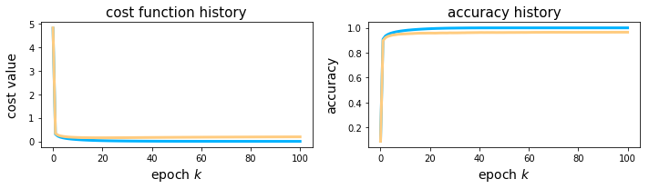

```python
mylib2.show_histories(start = 0)
```

Training and validation set accuracy.

```python
ind = np.argmax(mylib2.valid_count_histories[0])
best_val = mylib2.valid_count_histories[0][ind]
best_train = mylib2.train_count_histories[0][ind]
print(best_val,best_train)
```

```
0.9601999999999999 1.0
```

Compute test set accuracy.

```python
w_best = mylib2.weight_histories[0][ind]
test_evals = mylib2.model(x_test,w_best)
y_hat = (np.argmax(test_evals,axis = 0))[np.newaxis,:]
misses = np.argwhere(y_hat != y_test)

# compute predictions of each input point
acc = 1 - (misses.size/y_test.size)
print(acc)
```

[output not shown]